99 - chain, fork, and collider Chun Yu, Ko 2022-12-16

# 1 Type of betweeness

| Id | Between c and x | Between c and y |
| --- | --- | --- |
| 1 | ⫫ | ⫫ |
| 2 | → | ⫫ |
| 3 | ← | ⫫ |
| 4 | ⫫ | → |
| 5 | → | → |
| 6 | ← | → |
| 7 | ⫫ | ← |
| 8 | → | ← |
| 9 | ← | ← |

# 2 Estimation betweeness

## 2.1 1: c⫫x, c⫫y

c 與 x 或 c 與 y 均彼此獨立

此時檢定 y ~ x 則可觀察出真實效應

檢定 y ~ c 無結果（因彼此獨立）

檢定 y ~ x 並加入 c 調整與 y ~ x 無差，因 c 無解釋力

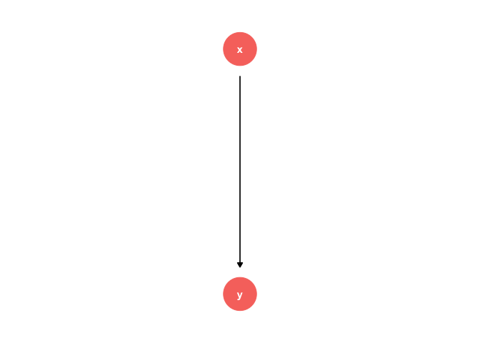

```r
sample_size = 100000
c <- rnorm(sample_size)
x <- rnorm(sample_size)
y <- .4 * x + rnorm(sample_size)

export_summs(lm(y ~ x), lm(y ~ c), lm(y ~ x + c), model.names = c("x", "c", "x + c"))
```

|  | x | c | x + c |
| --- | --- | --- | --- |
| (Intercept) | 0.00 | 0.00 | 0.00 |
|  | (0.00) | (0.00) | (0.00) |
| x | 0.40 *** |  | 0.40 *** |
|  | (0.00) |  | (0.00) |
| c |  | -0.00 | -0.00 |
|  |  | (0.00) | (0.00) |
| N | 100000 | 100000 | 100000 |
| R2 | 0.14 | 0.00 | 0.14 |
| *** p < 0.001; ** p < 0.01; * p < 0.05. |  |  |  |

## 2.2 2: c→x, c⫫y

形成 c x y chain

檢查 y ~ c 等同於檢查 x ~ y

調整 c 或 y 無意義，因 c 僅透過 x 影響 y

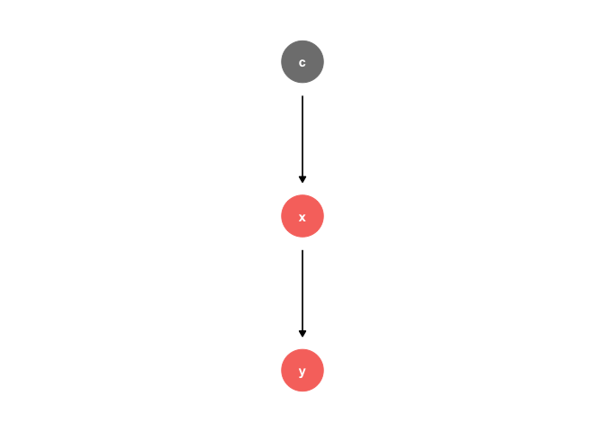

```r
c <- rnorm(sample_size)
x <- rnorm(sample_size) + 0.3 * c
y <- .4 * x + rnorm(sample_size)

export_summs(lm(y ~ x), lm(y ~ c), lm(y ~ x + c), model.names = c("x", "c", "x + c"))
```

|  | x | c | x + c |
| --- | --- | --- | --- |
| (Intercept) | -0.00 | -0.00 | -0.00 |
|  | (0.00) | (0.00) | (0.00) |
| x | 0.40 *** |  | 0.40 *** |
|  | (0.00) |  | (0.00) |
| c |  | 0.12 *** | 0.00 |
|  |  | (0.00) | (0.00) |
| N | 100000 | 100000 | 100000 |
| R2 | 0.15 | 0.01 | 0.15 |
| *** p < 0.001; ** p < 0.01; * p < 0.05. |  |  |  |

## 2.3 3: c←x, c⫫y

c 與 y 互為 x 之 child

y ~ x 與 y ~ x + c 無異

但 y ~ c 會出現假相關，可是為 y ~ c 之 collider, invert fork 為 x 所顯示的假相關

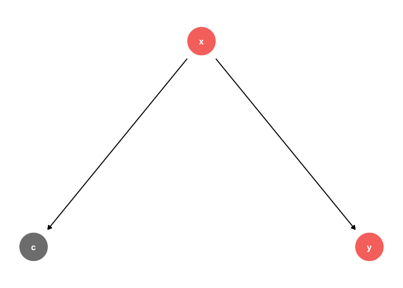

```r
x <- rnorm(sample_size)
c <- rnorm(sample_size) + 0.4 * x
y <- .4 * x + rnorm(sample_size)

export_summs(lm(y ~ x), lm(y ~ c), lm(y ~ x + c), model.names = c("x", "c", "x + c"))
```

|  | x | c | x + c |
| --- | --- | --- | --- |
| (Intercept) | 0.00 | 0.00 | 0.00 |
|  | (0.00) | (0.00) | (0.00) |
| x | 0.40 *** |  | 0.40 *** |
|  | (0.00) |  | (0.00) |
| c |  | 0.13 *** | -0.00 |
|  |  | (0.00) | (0.00) |
| N | 100000 | 100000 | 100000 |
| R2 | 0.14 | 0.02 | 0.14 |
| *** p < 0.001; ** p < 0.01; * p < 0.05. |  |  |  |

## 2.4 4: c⫫x, c→y

c 與 x 互為 y parent

y ~ x, y ~ c 均有不同意義

y ~ x + c 加入 c 調整更具解釋力 $R^2$

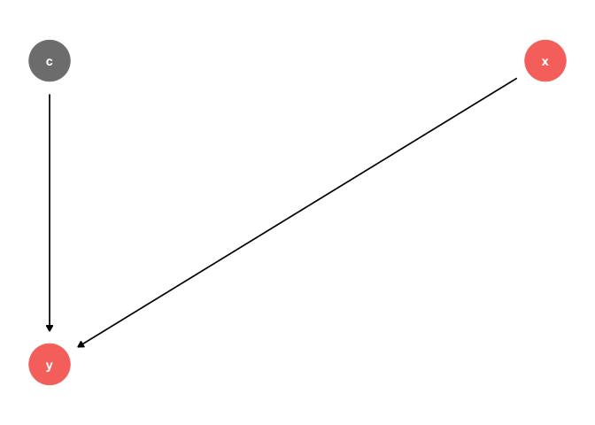

```r
x <- rnorm(sample_size)
c <- rnorm(sample_size)
y <- .4 * x + .6 * c + rnorm(sample_size)

export_summs(lm(y ~ x), lm(y ~ c), lm(y ~ x + c), model.names = c("x", "c", "x + c"))
```

|  | x | c | x + c |
| --- | --- | --- | --- |
| (Intercept) | 0.00 | 0.00 | 0.00 |
|  | (0.00) | (0.00) | (0.00) |
| x | 0.40 *** |  | 0.40 *** |
|  | (0.00) |  | (0.00) |
| c |  | 0.60 *** | 0.60 *** |
|  |  | (0.00) | (0.00) |
| N | 100000 | 100000 | 100000 |
| R2 | 0.10 | 0.24 | 0.34 |
| *** p < 0.001; ** p < 0.01; * p < 0.05. |  |  |  |

## 2.5 5: c→x, c→y

fork, confundering

此時 c 為 y ~ x 之混淆因子

檢定 y ~ x ，x 之估計不正確

檢定 y ~ c ，c 估計不正確

但檢定 y ~ x + c ，加入 c 調整則具意義與可解釋性

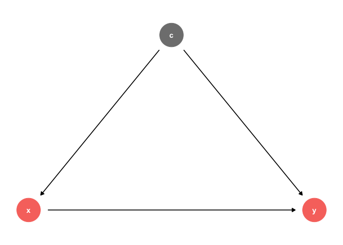

```r
c <- rnorm(sample_size)
x <- rnorm(sample_size) + .3 * c
y <- .4 * x + .6 * c + rnorm(sample_size)

export_summs(lm(y ~ x), lm(y ~ c), lm(y ~ x + c), model.names = c("x", "c", "x + c"))
```

|  | x | c | x + c |
| --- | --- | --- | --- |
| (Intercept) | -0.01 | -0.00 | -0.00 |
|  | (0.00) | (0.00) | (0.00) |
| x | 0.57 *** |  | 0.40 *** |
|  | (0.00) |  | (0.00) |
| c |  | 0.72 *** | 0.60 *** |
|  |  | (0.00) | (0.00) |
| N | 100000 | 100000 | 100000 |
| R2 | 0.21 | 0.31 | 0.40 |
| *** p < 0.001; ** p < 0.01; * p < 0.05. |  |  |  |

## 2.6 6: c←x, c→y

fork, confundering

此時 x 為 y ~ c 之混淆因子

檢定 y ~ c ，c 估計不正確

但檢定 y ~ x + c ，加入 c 調整則具意義與可解釋性

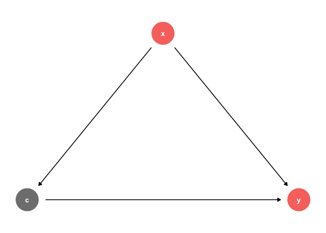

```r
x <- rnorm(sample_size)
c <- rnorm(sample_size) + .3 * x
y <- .4 * x + .6 * c + rnorm(sample_size)

export_summs(lm(y ~ x), lm(y ~ c), lm(y ~ x + c), model.names = c("x", "c", "x + c"))
```

|  | x | c | x + c |
| --- | --- | --- | --- |
| (Intercept) | -0.01 | -0.00 | -0.00 |
|  | (0.00) | (0.00) | (0.00) |
| x | 0.58 *** |  | 0.40 *** |
|  | (0.00) |  | (0.00) |
| c |  | 0.71 *** | 0.60 *** |
|  |  | (0.00) | (0.00) |
| N | 100000 | 100000 | 100000 |
| R2 | 0.20 | 0.32 | 0.41 |
| *** p < 0.001; ** p < 0.01; * p < 0.05. |  |  |  |

## 2.7 7: c⫫x, c←y

x y c chain

x 透過 y 影響 c

檢定 y ~ x 具意義

檢定 y ~ c 據另一層意義

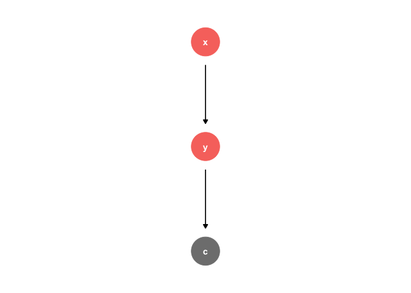

```r
x <- rnorm(sample_size)
y <- .4 * x + rnorm(sample_size)
c <- rnorm(sample_size) + .3 * y

export_summs(lm(y ~ x), lm(y ~ c), lm(y ~ x + c), model.names = c("x", "c", "x + c"))
```

|  | x | c | x + c |
| --- | --- | --- | --- |
| (Intercept) | 0.00 | 0.00 | 0.00 |
|  | (0.00) | (0.00) | (0.00) |
| x | 0.40 *** |  | 0.36 *** |
|  | (0.00) |  | (0.00) |
| c |  | 0.32 *** | 0.28 *** |
|  |  | (0.00) | (0.00) |
| N | 100000 | 100000 | 100000 |
| R2 | 0.14 | 0.10 | 0.21 |
| *** p < 0.001; ** p < 0.01; * p < 0.05. |  |  |  |

## 2.8 8: c→x, c←y

This is not a “DAG”

無法擬造數據不可估計

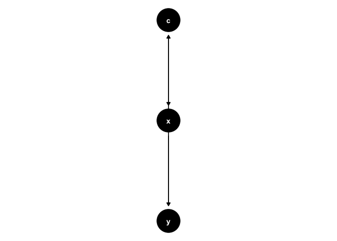

## 2.9 9: c←x, c←y

為 collider

y ~ x 可正常估計

但加入 c 會產生 y ~ x 假相關，估計不正確

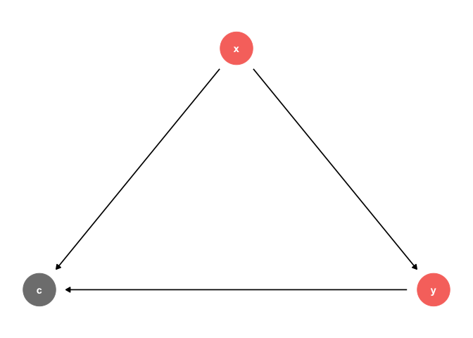

```r
x <- rnorm(sample_size)
y <- .4 * x + rnorm(sample_size)
c <- rnorm(sample_size) + .3 * y + .6 * x

export_summs(lm(y ~ x), lm(y ~ c), lm(y ~ x + c), model.names = c("x", "c", "x + c"))
```

|  | x | c | x + c |
| --- | --- | --- | --- |
| (Intercept) | 0.00 | 0.00 | 0.00 |
|  | (0.00) | (0.00) | (0.00) |
| x | 0.40 *** |  | 0.21 *** |
|  | (0.00) |  | (0.00) |
| c |  | 0.36 *** | 0.27 *** |
|  |  | (0.00) | (0.00) |
| N | 100000 | 100000 | 100000 |
| R2 | 0.14 | 0.18 | 0.21 |
| *** p < 0.001; ** p < 0.01; * p < 0.05. |  |  |  |

# 3 Summary of betweeness

| Id | Between c and x | Between c and y | Situation | Estimation of y ~ x | Estimation of y ~ c | Estimation of y ~ x + c |
| --- | --- | --- | --- | --- | --- | --- |
| 1 | ⫫ | ⫫ | X | Good | No need | No need |
| 2 | → | ⫫ | Chain | Good | No need | No need |
| 3 | ← | ⫫ | Collider | Good | Don’t | No need |
| 4 | ⫫ | → | X | Good | Good | Best |
| 5 | → | → | Fork | Don’t | Don’t | Good |
| 6 | ← | → | Fork | Good | Don’t | No need |
| 7 | ⫫ | ← | Chain | Good | Good | Don’t |
| 8 | → | ← | Impossible | X | X | X |
| 9 | ← | ← | Collider | Good | Don’t | Don’t |

# 4 Reference of confounder

## 4.1 Essentials of Epidemiology in Public Health - Chapter 11 Confounding

- the mixing of effects between an exposure, an outcome
- the association between the exposure and outcome is “distorted” because of the relationships between the confounder and the exposure and between the confounder and the outcome
- Confounding can be thought of as a failure of the comparison group to reflect the counterfactual experience of the exposed group.
- In other words, risk factors apart from the exposure are distributed differently between the exposed and unexposed groups when confounding is present

### 4.1.1 criteria of confounder

- the variable must be associated with the exposure in the population that produced the cases. That is, the confounding variable must be more or less common in the exposed group than in the comparison group
- the variable must be an independent cause or predictor of the disease, which means that the association between the confounder and the disease is present among both exposed and unexposed individuals
- a confounding variable cannot be an intermediate step in the causal pathway between the exposure and disease

### 4.1.2 how todetermine whether a variable is a confounder

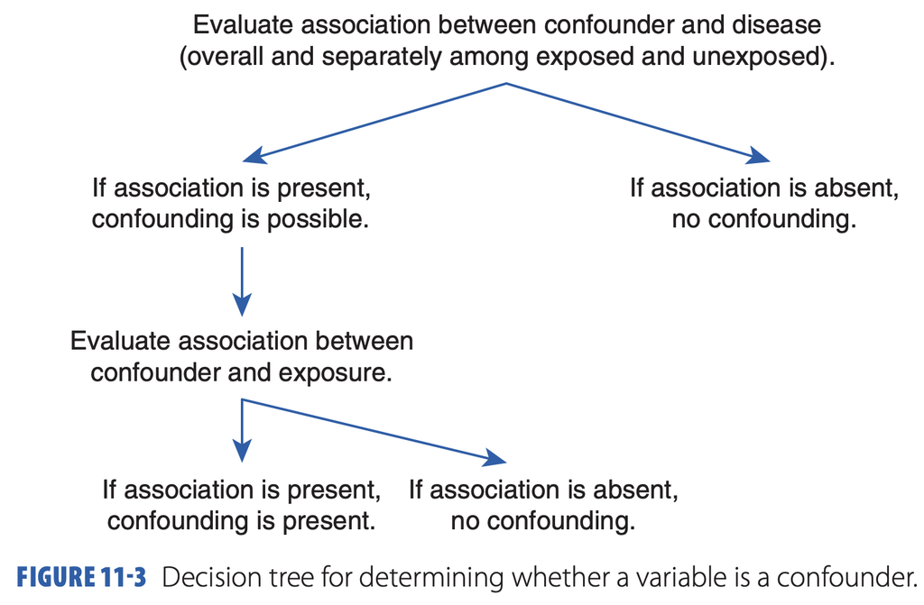

## 4.2 Others

- [Confounders are factors other than the exposure/intervention that may affect the outcome of interest and that can be related to exposure/intervention.](https://www.sciencedirect.com/science/article/pii/B9781416032915500081)
- [A confounder is a variable that is associated or has a relationship with both the exposure and the outcome of interest](https://www.sciencedirect.com/science/article/pii/B9780128142769000143)
- [A confounder is a factor that is related to the risk factor of interest and, independently of this, to outcome, but is not an intermediate factor on the causal path between the risk factor and outcome](https://www.sciencedirect.com/science/article/pii/B9780123751423100082)
- [In addition to confounders, there is a related but different phenomenon called interactions. Interactions are similar to confounding in that they can lead to misleading results, but they are fundamentally different in many significant ways. Perhaps the most important difference is that you can eliminate confounding by randomization, but you cannot eliminate interactions through randomization.](https://www.sciencedirect.com/science/article/pii/B9780123736956000156)
- [Confounding is a type of bias, because it causes biased estimates of associations. However, confounding is different from selection bias and information bias, because it is caused by an imbalance in other risk factors, and the investigators can adjust for confounding in the analysis phase in order to minimize its effects.](https://sphweb.bumc.bu.edu/otlt/MPH-Modules/PH717-QuantCore/PH717-Module11-Confounding-EMM/PH717-Module11-Confounding-EMM5.html)
- [A useful way to identify confounding is to calculate the crude (unadjusted) measure of association and then compute the measure of association again after adjusting for a possible confounding factor, as we did above. If the two differ, it suggests that the factor we adjusted for was a confounder.](https://sphweb.bumc.bu.edu/otlt/MPH-Modules/PH717-QuantCore/PH717-Module11-Confounding-EMM/PH717-Module11-Confounding-EMM5.html)
- [Many epidemiologic studies are planned to examine the causal association of exposure with the outcome of interest using non-experimental (observational) or experimental data. By definition, for judging causal inference, the following three criteria simultaneously should be satisfied: 1) exposure must be proceeded from outcome ; 2) a statistical association should be revealed between exposure and outcome i.e. any changes on exposure status yields changes on outcome; 3) the apparent association must be valid.](https://www.ncbi.nlm.nih.gov/pmc/articles/PMC3755849/)